#’ title: “Classification by Random Forests” #’ author: “Fabian Garrett” #’ date: “25/02/2023” #’ output: #’ —————————————————————— #’ Introduction to Machine Learning in R | ISLA Gaia #’ —————————————————————— #’ # Exercise #’ Consider the “Wholesale Customers Data Set” from the UCI Machine Learning #’ Repository at  
#’ https://archive.ics.uci.edu/ml/datasets/wholesale+customers #’ This data set refers to clients of a wholesale distributor in Portugal. #’ It includes the annual spending in monetary units (m.u.) on diverse #’ product categories: Fresh, Milk, Grocery, Frozen, #’ Detergents_Paper, Delicassen. #’ It also includes 2 categorical variables: Channel (Horeca, Retail) and #’ Region (Lisbon, Porto, Other). #’ ## Tasks #’ 1. Train a model to correctly classify customers by Channel #’ (Horeca vs Retail), using the **Random Forests** algorithm. #’ 2. Compile a commented report in PDF or HTML directly from RStudio. #’ ## Tips: #’ - Explore the dataset. #’ - Split the full data set in Train and Test sets: #’ Train the model(s) using the Train set; #’ Validate the model with the Test set. #’ - Comment the results. #’ - To compile a report in PDF or HTML directly from RStudio, click from #’ menu *File* > *Compile Report…* #’ (this may require pre-installing packages ‘knitr’ and ‘rmarkdown’). #’ —————————————————————— # Read dataset directly from UCI repository ——————————-

```r
url_path <- paste0("https://archive.ics.uci.edu/ml/machine-learning-databases/",
                   "00292/Wholesale%20customers%20data.csv")
wholesale <- read.csv(url_path, sep = ",")
rm(url_path)
```

#Load library

```r
library(caret)
```

# Label categorical variables

```r
wholesale$Region <- factor(wholesale$Region, levels = 1:3,
                           labels = c("Lisbon", "Porto", "Other"))
wholesale$Channel <- factor(wholesale$Channel, levels = 1:2,
                            labels = c("Horeca", "Retail"))
head(wholesale)
```

```
##   Channel Region Fresh Milk Grocery Frozen Detergents_Paper Delicassen
## 1  Retail  Other 12669 9656    7561    214             2674       1338
## 2  Retail  Other  7057 9810    9568   1762             3293       1776
## 3  Retail  Other  6353 8808    7684   2405             3516       7844
## 4  Horeca  Other 13265 1196    4221   6404              507       1788
## 5  Retail  Other 22615 5410    7198   3915             1777       5185
## 6  Retail  Other  9413 8259    5126    666             1795       1451
```

```r
str(wholesale)
```

```
## 'data.frame':    440 obs. of  8 variables:
##  $ Channel         : Factor w/ 2 levels "Horeca","Retail": 2 2 2 1 2 2 2 2 1 2 ...
##  $ Region          : Factor w/ 3 levels "Lisbon","Porto",..: 3 3 3 3 3 3 3 3 3 3 ...
##  $ Fresh           : int  12669 7057 6353 13265 22615 9413 12126 7579 5963 6006 ...
##  $ Milk            : int  9656 9810 8808 1196 5410 8259 3199 4956 3648 11093 ...
##  $ Grocery         : int  7561 9568 7684 4221 7198 5126 6975 9426 6192 18881 ...
##  $ Frozen          : int  214 1762 2405 6404 3915 666 480 1669 425 1159 ...
##  $ Detergents_Paper: int  2674 3293 3516 507 1777 1795 3140 3321 1716 7425 ...
##  $ Delicassen      : int  1338 1776 7844 1788 5185 1451 545 2566 750 2098 ...
```

# Exercise —————————————————————-

# Train a model to correctly classify customers by Channel (Horeca vs Retail)

# Classification class distribution in full dataset

```r
freq_table <- table(wholesale$Channel)
cbind(Frequency = freq_table,
      Proportion = round(prop.table(freq_table), 3))
```

```
##        Frequency Proportion
## Horeca       298      0.677
## Retail       142      0.323
```

# Define train and test sets ———————————————-

```r
seed <- 541
set.seed(seed)
train_index <- createDataPartition(wholesale$Channel, p = 0.8, list = FALSE)
train_set <- wholesale[train_index, ]
test_set  <- wholesale[-train_index, ]
```

# Compare Decision Tree vs Random Forest ———————————-

# Note 1:

# To minimize generalization error, run algorithms using

# 3 times 5-fold cross validation.

# Note 2:

# As performance metric, we’ll use the Area Under the ROC curve

# We’ll use function trainControl to setup the training parameters

# of the model. For further info, check ?caret::trainControl()

```r
metric <- "ROC"
control <- trainControl(method = "repeatedcv",
                        number = 5, # number of folds
                        repeats = 3, # number of repetitions
                        summaryFunction = twoClassSummary,
                        classProbs = TRUE,
                        savePredictions = TRUE)
```

# Learn Decision Tree (rpart)

```r
set.seed(seed)
model_DT <- train(Channel ~ .,
                  data = train_set,
                  method = "rpart", # Decision Trees, with CART algorithm
                  metric = metric,
                  trControl = control)
```

# Learn Random Forest (rf)

```r
set.seed(seed)
model_RF <- train(Channel ~ .,
                  data = train_set,
                  method = "rf",  # Random Forests
                  metric = metric,
                  trControl = control)
```

#’ Check models, metrics and specific tunning parameters #’ cp: Complexity parameter #’ mtry: Number of randomly drawn candidate variables

```r
print(model_DT)
```

```
## CART
##
## 353 samples
##   7 predictor
##   2 classes: 'Horeca', 'Retail'
##
## No pre-processing
## Resampling: Cross-Validated (5 fold, repeated 3 times)
## Summary of sample sizes: 282, 282, 283, 283, 282, 283, ...
## Resampling results across tuning parameters:
##
##   cp          ROC        Sens       Spec
##   0.01754386  0.9119665  0.9162530  0.8303030
##   0.06140351  0.9062788  0.8967199  0.9086957
##   0.70175439  0.7627883  0.9176714  0.6079051
##
## ROC was used to select the optimal model using the largest value.
## The final value used for the model was cp = 0.01754386.
```

```r
print(model_RF)
```

```
## Random Forest
##
## 353 samples
##   7 predictor
##   2 classes: 'Horeca', 'Retail'
##
## No pre-processing
## Resampling: Cross-Validated (5 fold, repeated 3 times)
## Summary of sample sizes: 282, 282, 283, 283, 282, 283, ...
## Resampling results across tuning parameters:
##
##   mtry  ROC        Sens       Spec
##   2     0.9454346  0.9247045  0.8333333
##   5     0.9414352  0.9163121  0.8420290
##   8     0.9382730  0.9191489  0.8478261
##
## ROC was used to select the optimal model using the largest value.
## The final value used for the model was mtry = 2.
```

#’ Calculate and compare models’ performance #’ Note: #’ - We’ll use function ‘resamples()’ for visualization #’ of the resampling results #’ - These calculations are based on resampling the TRAIN set

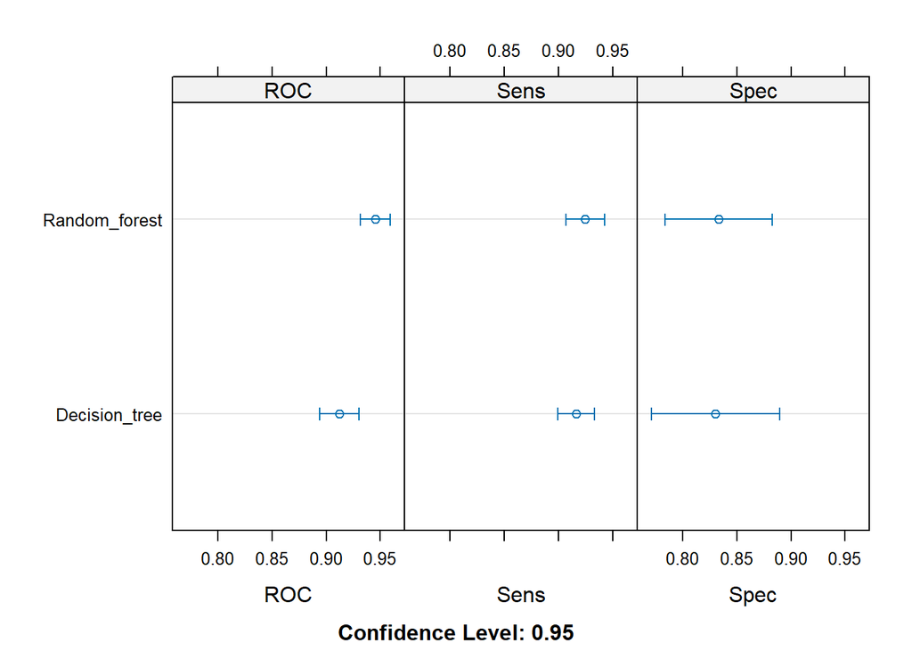

```r
fit_models <- list(Decision_tree = model_DT,
                   Random_forest = model_RF)
results <- resamples(fit_models)
dotplot(results)
```

```r
summary(results)
```

```
##
## Call:
## summary.resamples(object = results)
##
## Models: Decision_tree, Random_forest
## Number of resamples: 15
##
## ROC
##                    Min.   1st Qu.    Median      Mean   3rd Qu.      Max. NA's
## Decision_tree 0.8465909 0.8999506 0.9209280 0.9119665 0.9269966 0.9574275    0
## Random_forest 0.8935688 0.9281048 0.9533514 0.9454346 0.9630888 0.9791667    0
##
## Sens
##                    Min.   1st Qu.    Median      Mean   3rd Qu.      Max. NA's
## Decision_tree 0.8723404 0.8958333 0.9148936 0.9162530 0.9270833 0.9791667    0
## Random_forest 0.8541667 0.9157801 0.9166667 0.9247045 0.9368351 0.9791667    0
##
## Spec
##                    Min.   1st Qu.   Median      Mean   3rd Qu.      Max. NA's
## Decision_tree 0.6521739 0.7391304 0.826087 0.8303030 0.9130435 0.9565217    0
## Random_forest 0.6956522 0.7826087 0.826087 0.8333333 0.8913043 1.0000000    0
```

# Check Complexity Parameter (cp) used for trained model

```r
print(model_DT$results$cp)
```

```
## [1] 0.01754386 0.06140351 0.70175439
```

# Plot ROC vs Complexity Parameter for model

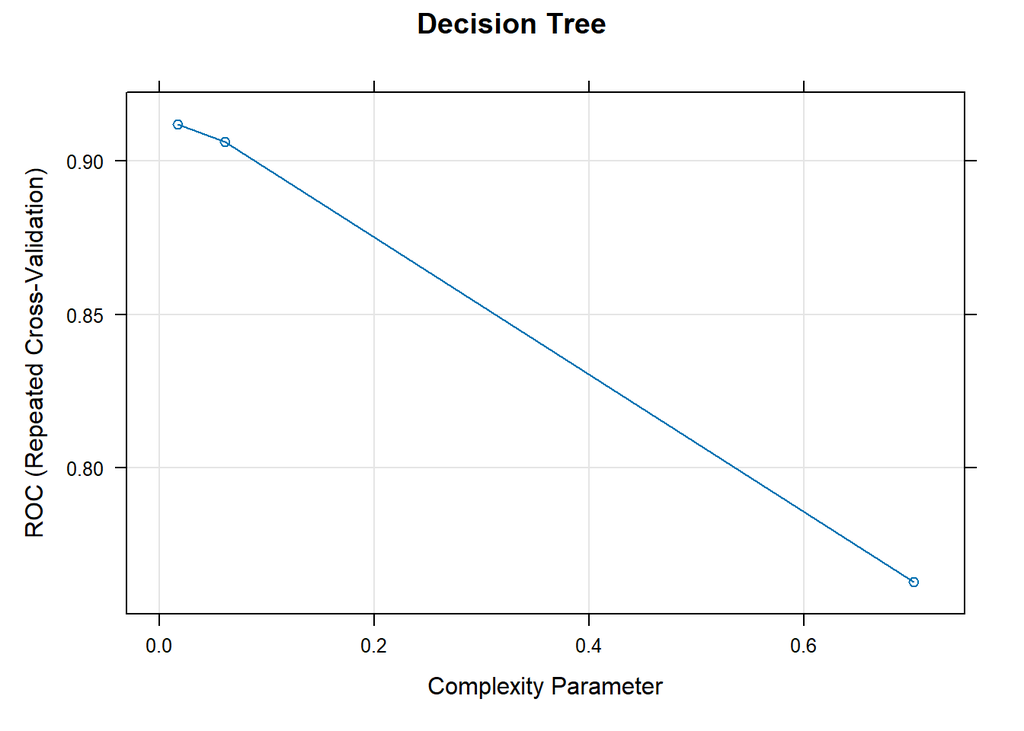

```r
plot(model_DT, main = "Decision Tree")
```

# Check mtry parameter used for trained model # getModelInfo(model_RF)$rf$parameters

```r
print(model_RF$results$mtry)
```

```
## [1] 2 5 8
```

#Plot ROC vs used parameters for model

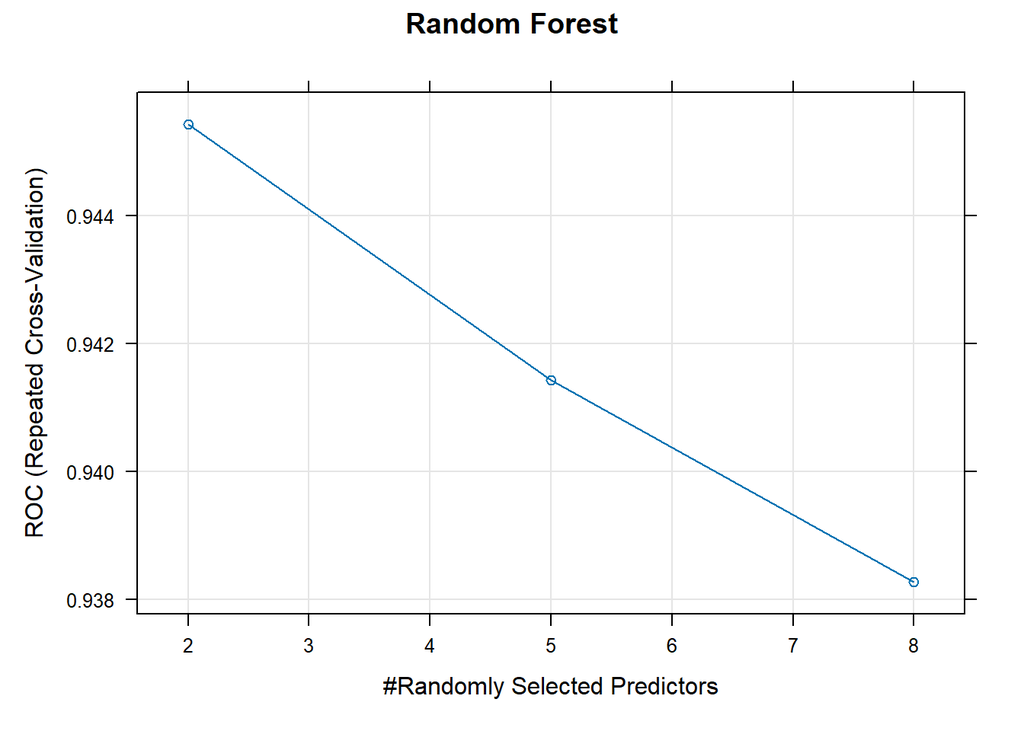

```r
plot(model_RF, main = "Random Forest")
```

# Improve the Random Forest model —————————————–

# To improve the RF model, we fine tune the mtry parameter

```r
tune_grid <- expand.grid(mtry = 1:10)

set.seed(seed)
model_RF_tuned <- train(Channel ~ .,
                       data = train_set,
                       method = "rf",
                       metric = metric,
                       trControl = control,
                       tuneGrid = tune_grid)
```

[output not shown]

[output cut: 34 more lines]

[output not shown]

# Inspect model

```r
print(model_RF_tuned)
```

```
## Random Forest
##
## 353 samples
##   7 predictor
##   2 classes: 'Horeca', 'Retail'
##
## No pre-processing
## Resampling: Cross-Validated (5 fold, repeated 3 times)
## Summary of sample sizes: 282, 282, 283, 283, 282, 283, ...
## Resampling results across tuning parameters:
##
##   mtry  ROC        Sens       Spec
##    1    0.9449506  0.9344858  0.8187088
##    2    0.9450909  0.9218972  0.8333333
##    3    0.9427148  0.9205083  0.8362319
##    4    0.9429440  0.9163121  0.8391304
##    5    0.9405062  0.9149232  0.8391304
##    6    0.9397686  0.9163712  0.8391304
##    7    0.9392212  0.9163416  0.8420290
##    8    0.9368918  0.9191489  0.8420290
##    9    0.9377255  0.9191489  0.8420290
##   10    0.9354676  0.9177600  0.8449275
##
## ROC was used to select the optimal model using the largest value.
## The final value used for the model was mtry = 2.
```